# Principal Components Analysis

- Introduction to principal components analysis (PCA)
- Plotting principal components
- Principal components regression (PCR)

# Introduction to PCA

## High-Dimensional Data

- All of our genetic data (expression, methylation, copy number) are high-dimensional. This means the number of features (genes, DNA segments) is much larger than the number of cases (cell lines).
  - Expression: 850 x 17,737
  - Methylation: 850 x 485,512
  - Copy number: 850 x 46,221
- We use the notation $n$ to represent the number of cases and $p$ to represent the number of features.
  - High-dimensional data is when $p > n$ (and often, $p >> n$).
- In high-dimensional settings, PCA can be used as a method of dimension reduction -- identifying a lower-dimensional set of features from a very high-dimensional set.

### Dimension Reduction

There are many methods of dimension reduction that are used with high-dimensional data.

- Choosing a subset of the features that captures the variation in the data.
  - For example, suppose all cell lines have basically the same expression levels for 17,700 genes and very different expression levels for 37 genes. Then we can reduce the dimension of our data by only focusing on the 37 important genes.
- Take linear combinations of the original features to create new features that capture the variation in the data.
  - The number of linear combinations may be much smaller than the number of original features.
  - This is a transformation of the data, which loses interpretability.

## PCA in Two-Dimensions

Although we are talking about PCA as a dimension reduction technique, we will consider the two-dimensional case ($p = 2$) to begin with.

Example (from *Introduction to Statistical Learning*):

- The data we will consider consists of population size and spending on advertisments for 100 small cities.
- Plotted data appears in thousands of people for population size and thousands of dollars for advertising spending.

### What is PCA?

PCA is a method that identifies the directions that contain most of the variation in the data.

- first PC direction: the direction in which the data vary the most.
  - If we were to project the data onto that line, the projected observations would have greater variance than if we had projected them onto any other line.
- second PC direction: the direction in which the data vary the most that is perpendicular to the first PC direction.

The maximum number of principal components is equal to the number of original features.

[figure not shown]

### Mathematical Representation

The first principal component direction can be writted mathematically:

$$ Z_1 = 0.839 \times (pop - \overline{pop}) + 0.544 \times (ad - \overline{ad}) $$

- This is the equation for the line in the first principal component direction.
- The vector that results from plugging the data into this equation contains what are called the first PC scores. These are the projection of the data onto the first PC direction.

There is also an equation for the second principal component direction and a similar vector of second PC scores, but we will focus on PC1 because we want to reduce the dimension of our problem.

### PC Scores

These are a transformation (a linear combination) of the original data.

- Each of the elements in the vector of PC scores is a single number that summarizes the population size and the advertising spending for that city.
- This is the idea of dimension reduction -- we have gone from two features describing our data (population size and ad spending) to one.
  - Ideally, that one new feature contains most of the important information from the two original features.

## PCA in Higher-Dimensions

In higher dimensions, the idea is exactly the same, but it becomes much more difficult to visualize.

- Each PC points in the direction of largest variation that is perpendicular to the previous PC directions.
- The maximum number of PCs is the total number of features in the data ($p$).
- A good number of PCs to use is a tuning parameter ($k$).
  - When choosing $k$, we want to balance simplicity and information loss.
  - How to choose $k$? Cross-validation!

## PCA in R

To do PCA in R, we will use the *svd( )* function and will need to specify the data and the number of PCs we are interested in. We can then use this output to calculate the PC scores.

```r
# read in the screening and expression data
screen.dat <- readRDS("/Users/zoerehnberg/Documents/BDSI 2018/final data/screening.rds")
expr.dat <- readRDS("/Users/zoerehnberg/Documents/BDSI 2018/final data/expression.rds")
```

Let's look at drug 1014.

```r
# subset to drug 1014
classes.1014 <- subset(screen.dat, DRUG_ID_lib == "1014")[,c("CL","EFFECT")]
expr.1014 <- expr.dat[as.character(classes.1014$CL),]
dim(expr.1014)
```

1. 246

2. 17737

```r
# first, we need to center the expression data by column means
center.expr <- scale(expr.1014)

# now, we can do PCA
pca <- svd(center.expr, nu = 3, nv = 0)
```

```r
pc.scores <- as.data.frame(diag(pca$d) %*% pca$u)
pc.scores <- cbind(classes.1014, pc.scores)

dim(pc.scores)
head(pc.scores)
```

1. 246

2. 5

|  | CL | EFFECT | V1 | V2 | V3 |
| --- | --- | --- | --- | --- | --- |
| 30 | 683667 | FALSE | -2.296577 | 13.286341 | -42.46631 |
| 52 | 684055 | FALSE | 8.833259 | 36.338098 | -28.65888 |
| 89 | 684059 | FALSE | 1.410772 | 16.206773 | -21.20815 |
| 114 | 684062 | FALSE | 11.094054 | 32.253806 | -18.23504 |
| 261 | 687457 | TRUE | -17.400046 | -7.395096 | 19.02603 |
| 512 | 687592 | TRUE | -15.600563 | 6.847895 | -17.75152 |

# Plotting Principal Components

## Visualizing High-Dimensional Data

One of the first things to do when exploring data is to visualize it in as many ways as possible, but it can be difficult to know how to do that when the data is high-dimensional.

- How can you plot 17,737-dimensional data?
- What does 17,737-dimensional space really look like?

### Plot PC Scores

Instead of plotting the original data, we can plot the PC scores of the first few principal components.

- We can view an approximation of 17,737-dimensional data in two-dimensions.
- This allows us to visualize variation in the data because the largest amount of variation is captured in the first few PCs.
- We can look for clustering or separation in the data.

```r
library(ggplot2)
options(repr.plot.width = 5, repr.plot.height = 3)
```

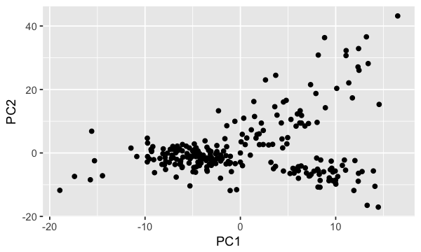

```r
ggplot(data = pc.scores) + geom_point(aes(x = V1, y = V2)) + labs(x = "PC1", y = "PC2")
```

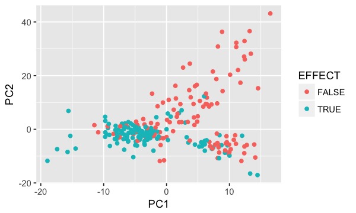

```r
ggplot(data = pc.scores) + geom_point(aes(x = V1, y = V2, color = EFFECT)) + labs(x = "PC1", y = "PC2")
```

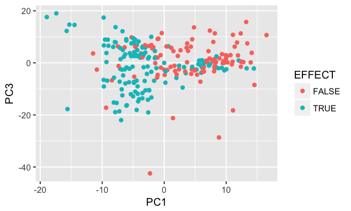

```r
ggplot(data = pc.scores) + geom_point(aes(x = V1, y = V3, color = EFFECT)) + labs(x = "PC1", y = "PC3")
```

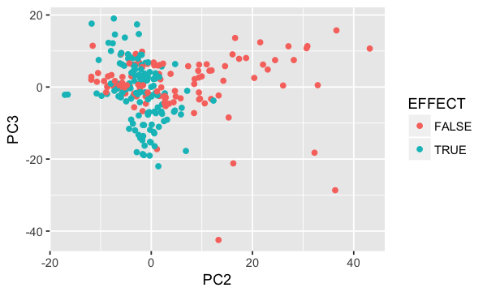

```r
ggplot(data = pc.scores) + geom_point(aes(x = V2, y = V3, color = EFFECT)) + labs(x = "PC2", y = "PC3")
```

### Conclusions

These plots, especially PC1 vs. PC2, indicate that a large source of the variation in the expression data is related to the effectiveness of drug 1014.

# Principal Components Regression (PCR)

## The Method

- Find the first $k$ principal components of the features.
- Use those principal components as predictors and regress the response onto them.

## The Idea

- We are assuming that the first $k$ principal components contain the relevant information about the response.
- In other words, the directions of highest variability in the expression data, which are captured in the first $k$ principal components, are the directions associated with drug effectiveness.
  - If we have chosen a good predictor, this assumption turns out to be reasonably true.
- If this assumption is true, then the results of the regression will be better than when using all the original predictors in the model.
  - $n > p$: we reduce the risk of overfitting by only estimating $k < p$ coefficients.
  - $n < p$: we cannot estimate more coefficients than the number of observations we have.

### PCR in R

To do PCR in R, we will use the *pcr( )* function in the *pls* package.

```r
# install.packages("pls")
library("pls")
```

```r
# split the centered data into training and testing
n <- dim(center.expr)[1]
train.index <- sample(1:n, n/2)

# training set
x.train <- center.expr[train.index,]
y.train <- classes.1014[train.index,]
train.dat <- data.frame(class = y.train$EFFECT, x.train)

# testing set
x.test <- center.expr[-train.index,]
y.test <- classes.1014[-train.index,]
test.dat <- data.frame(class = y.test$EFFECT, x.test)

dim(x.train)
dim(y.train)
```

1. 123

2. 17737

1. 123

2. 2

```r
# we are going to use a subset of the data for this example
train.dat <- train.dat[,1:10000]
test.dat <- test.dat[,1:10000]
```

```r
train.dat[1:6,1:6]
```

|  | class | ENSG00000000003 | ENSG00000000005 | ENSG00000000419 | ENSG00000000457 | ENSG00000000460 |
| --- | --- | --- | --- | --- | --- | --- |
| 687592 | TRUE | 0.5865919 | 0.1590330 | -0.2044743 | -0.4630421 | -0.46160463 |
| 753599 | FALSE | 0.8033582 | -0.2526648 | -0.3376447 | -0.6412932 | 0.12522595 |
| 1290907 | TRUE | 0.9287135 | -1.3323959 | 0.1461197 | 1.0109049 | -0.17493187 |
| 906865 | TRUE | 0.3139403 | 0.1111352 | -0.2884500 | -0.5497286 | 0.93660056 |
| 1240143 | TRUE | 0.4876648 | 0.7434003 | -2.4603983 | -0.2323499 | -0.53600607 |
| 688006 | FALSE | 0.6678016 | 0.5905248 | -1.0135873 | -0.4228838 | 0.00928635 |

```r
# do PCR for the training data
pcr.fit <- pcr(class ~ ., data = train.dat, scale = TRUE, ncomp = 10)
```

```r
# now use that fit to get predictions for the testing data
pcr.pred <- predict(pcr.fit, test.dat, ncomp = 10)
preds <- ifelse(pcr.pred >= 0.5, 1, 0)

# get the classification success rate
mean(preds == y.test$EFFECT)
```

0.804878048780488

### Conclusions

- PCR can be a good approach if a small number of features contain the majority of the important information.
- PCR doesn't do any variable selection.
- PCR uses transformations of the features, so it lacks interpretability.

# To-Do

Choose another drug/drugs and do PCA. Look at some PC plots and color them by class label. Try PCR for those drugs.

### Further Reading:

- *Introduction to Statistical Learning* (James, Witten, Hastie, Tibshirani): https://www.ime.unicamp.br/~dias/Intoduction%20to%20Statistical%20Learning.pdf